# Regularization in Linear Models

## Visualize the features and weights

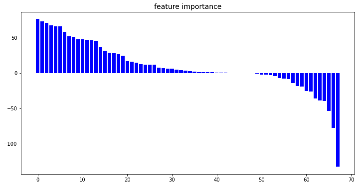

```python
feature_importance(weights)
```

## Ridge Regression: RidgeCV

- Explore that if RidgeCV can improve the estimation accuracy since the data contains variables that highly correlated. Through L2 regularization (adding bias), the variance of the estimates can be reduced.
- Thorugh observing the results, it turns out that the r2 score for the test data has not been improved.

```python
# coss-validation test
alphas = np.linspace(0.0001,0.1,200)
ridge_cv = RidgeCV(alphas=alphas, normalize=True, cv = 5)
# , scoring="neg_mean_squared_error")
ridge_cv.fit(x_train, y_train)
# find the best alpha
alpha = ridge_cv.alpha_
print ('best alpha:')
print (alpha)
```

```
best alpha:
0.015662311557788945
```

```
r2_score_test: 0.6820
r2_score_train: 0.6775
mse_test: 2736.85
mse_train: 2617.74
```

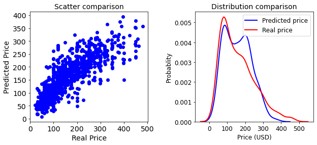

```python
ridge = Ridge(alpha = alpha, normalize=True)
ridge_weights = model_evaluation(ridge)
```

## Visualize the features and weights

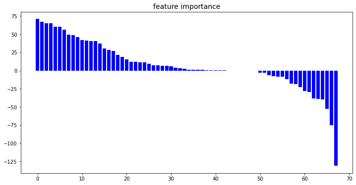

```python
feature_importance(ridge_weights)
```

```
r2_score_test: 0.6088
r2_score_train: 0.6059
mse_test: 3366.94
mse_train: 3199.33
```

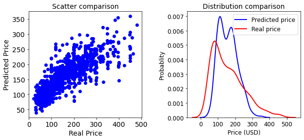

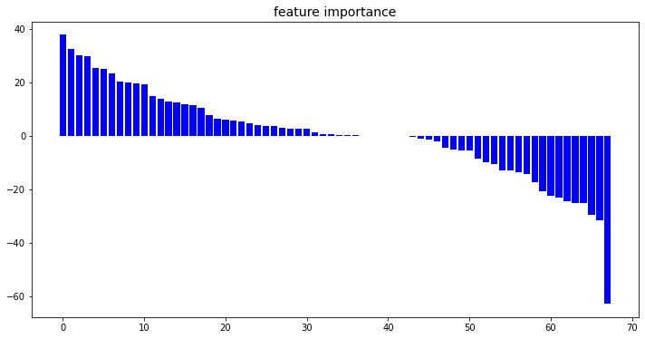

```python
## Try a larger alpha to see the L2 regularization effect
ridge = Ridge(alpha = 1, normalize=True)
ridge_weights = model_evaluation(ridge)
feature_importance(ridge_weights)
```

## Lasso Regression: LassoCV

- Explore that if LassoCV can improve the estimation accuracy since the data contains variables that highly correlated. Through L1 regularization (adding bias), the variance of the estimates can be reduced.
- Thorugh observing the results, it turns out that the r2 score for the test data has not been improved.

```python
# coss-validation test
lasso_cv = LassoCV(normalize=True, cv = 5)
# , scoring="neg_mean_squared_error")
lasso_cv.fit(x_train, y_train)
# find the best alpha
alpha = lasso_cv.alpha_
print ('best alpha:')
print (alpha)
```

```
best alpha:
0.006191460063933275
```

```
r2_score_test: 0.6822
r2_score_train: 0.6778
mse_test: 2735.23
mse_train: 2615.85
```

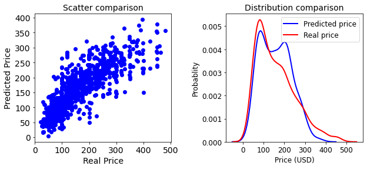

```python
lasso = Lasso(alpha = alpha, normalize=False)
lasso_weights = model_evaluation(lasso)
```

## Visualize the features and weights

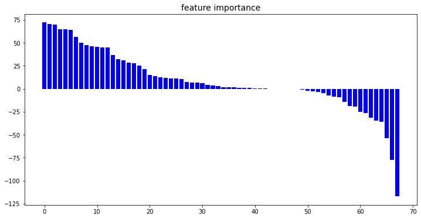

```python
feature_importance(lasso_weights)
```

```
r2_score_test: 0.6143
r2_score_train: 0.6094
mse_test: 3319.33
mse_train: 3171.18
```

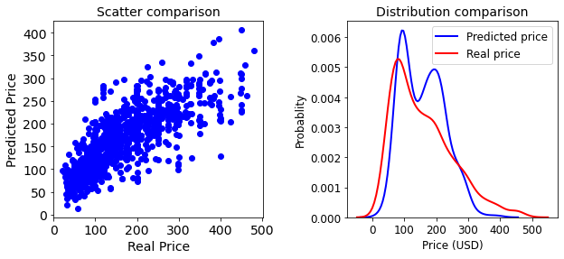

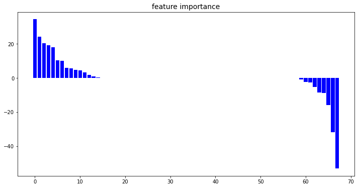

```python
# try a larger alpah to see the L1 regularization effect
lasso = Lasso(alpha = 1, normalize=False)
lasso_weights = model_evaluation(lasso)
feature_importance(lasso_weights)
```

## ElasticNet Regression: ElasticNetCV

```
Combination of L1 and L2 regularization
```

```python
# coss-validation test
EN_cv = ElasticNetCV(l1_ratio = 0.2, normalize=True, cv = 5)
# , scoring="neg_mean_squared_error")
EN_cv.fit(x_train, y_train)
# find the best alpha
alpha = EN_cv.alpha_
print ('best alpha:')
print (alpha)
```

```
best alpha:
0.00540987614961839
```

```
r2_score_test: 0.6796
r2_score_train: 0.6733
mse_test: 2757.57
mse_train: 2652.21
```

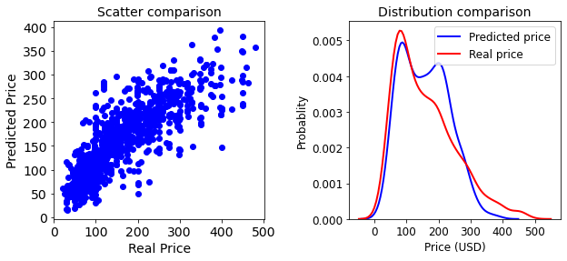

```python
EN = ElasticNet(alpha = alpha, l1_ratio=0.5, normalize=False)
EN_weights = model_evaluation(EN)
```